# Regression Problem_new

### Model7: Random Forest

```python
from sklearn.ensemble import RandomForestRegressor
model7 = RandomForestRegressor(n_estimators = 246,
                               oob_score = True,
                               max_features = 'sqrt',
                               max_depth = 26,
                               min_samples_split = 20,
                               min_samples_leaf = 1)

model7.fit(X_train, logy_train)
y_pred_model7 = model7.predict(X_test)
y_pred_model7 = np.exp(y_pred_model7)
abs_err_model7 = np.abs(y_pred_model7 - y_test)
```

```python
from sklearn.model_selection import RandomizedSearchCV
n_estimators = [int(x) for x in np.linspace(start = 100, stop = 2000, num = 40)]
max_features = ['auto', 'sqrt']
max_depth = [int(x) for x in np.linspace(5, 40, num = 6)]
min_samples_split = [2, 5, 10, 15, 20,25,30,35,40,100]
min_samples_leaf = [1, 2, 5, 10]

random_grid = {'n_estimators': n_estimators,
               'max_features': max_features,
               'max_depth': max_depth,
               'min_samples_split': min_samples_split,
               'min_samples_leaf': min_samples_leaf}

rf_random = RandomizedSearchCV(estimator = model7,
                               param_distributions = random_grid,
                               scoring='neg_mean_squared_error',
                               n_iter = 10,
                               cv = 5,
                               verbose=2,
                               random_state=42,
                               n_jobs = 1)

rf_random.fit(X_train, logy_train);
rf_random.best_params_
```

[output not shown]

[output cut: 17 more lines]

```
{'n_estimators': 1561,
 'min_samples_split': 20,
 'min_samples_leaf': 2,
 'max_features': 'sqrt',
 'max_depth': 12}
```

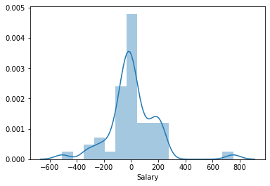

```python
sns.distplot(y_test - y_pred_model7)
```

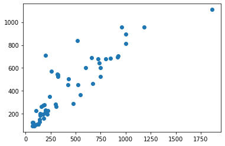

```python
plt.scatter(y_test , y_pred_model7)
```

```python
print('MAE:', metrics.mean_absolute_error(y_test, y_pred_model7))
print('MSE:', metrics.mean_squared_error(y_test, y_pred_model7))
print('RMSE:', np.sqrt(metrics.mean_squared_error(y_test, y_pred_model7)))
```

```
MAE: 116.0055406456813
MSE: 31734.622301867523
RMSE: 178.14214072438762
```

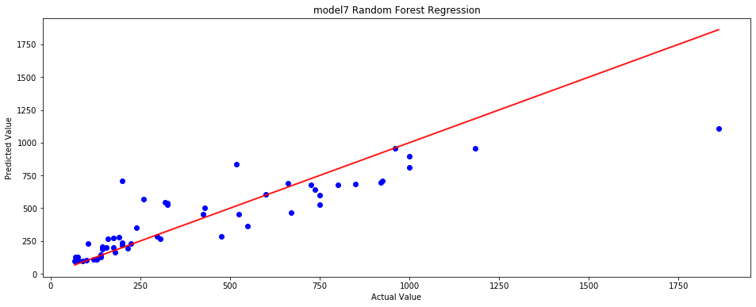

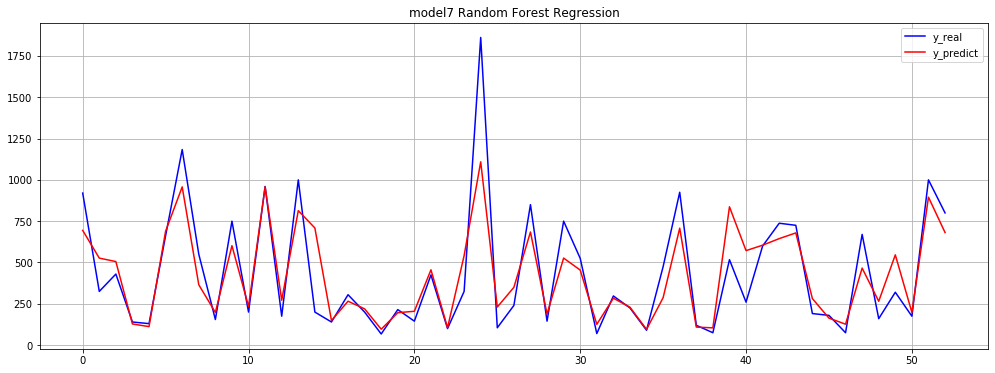

```python
from sklearn.metrics import r2_score

y_pred = y_pred_model7
y_test = y_test
model = 'model7 Random Forest Regression'

plt.figure(figsize=(15, 15), dpi = 150);
plt.subplots_adjust(hspace = 0.25, wspace = 0.25);

plt.subplots(figsize=(16,6));
plt.scatter(x = y_test, y = y_pred, color = 'blue');
#Add 45 degree line
xp = np.linspace(y_test.min(), y_test.max(), 100)
plt.plot(xp, xp, 'k', alpha = 0.9, linewidth = 2, color = 'red')
plt.xlabel('Actual Value');
plt.ylabel('Predicted Value');

plt.title(f'{model}');
plt.subplots(figsize=(17,6));

x_points = list(range(len(y_test)));
plt.plot(x_points, y_test, label='y_real', color = 'blue');
plt.plot(x_points, y_pred, label='y_predict', color = 'red');
plt.legend();
plt.grid()
plt.title(f'{model}');
plt.show();
```

```python
model_comp = model_comp.append(pd.DataFrame({'Mean of AbsErrors':    abs_err_model7.mean(),
                                             'Median of AbsErrors' : abs_err_model7.median(),
                                             'SD of AbsErrors' :     abs_err_model7.std(),
                                             'IQR of AbsErrors':     iqr(abs_err_model7),
                                             'Min of AbsErrors':     abs_err_model7.min(),
                                             'Max of AbsErrors':     abs_err_model7.max()}, index = ['Model7: Random Forest Regression']),
                               ignore_index = False)

model_comp
```

|  | Mean of AbsErrors | Median of AbsErrors | SD of AbsErrors | IQR of AbsErrors | Min of AbsErrors | Max of AbsErrors |
| --- | --- | --- | --- | --- | --- | --- |
| Model1: Linear-Ragression | 223.148958 | 158.574170 | 198.785517 | 216.725217 | 3.569232 | 1047.957143 |
| Model2: Ridge Regression | 226.441674 | 151.029550 | 293.532084 | 136.707544 | 7.679097 | 1897.768941 |
| Model3: Lasso Regression | 235.833326 | 142.116905 | 324.730397 | 156.625954 | 3.744212 | 2181.596147 |
| Model4: KNN Regression | 160.407478 | 81.167175 | 190.775927 | 226.393202 | 2.543116 | 837.841616 |
| Model5: Decision Tree Regression | 162.989272 | 78.558773 | 185.351198 | 223.772135 | 0.769051 | 827.083624 |
| Model6: Bagging Regression | 108.270063 | 53.318368 | 135.012977 | 139.730651 | 0.721212 | 712.250993 |
| Model7: Random Forest Regression | 116.005541 | 70.955476 | 136.487450 | 163.104426 | 1.779497 | 752.332797 |

### Model8: Gradient Boost Regression

```python
from sklearn.ensemble import GradientBoostingRegressor
model8 = GradientBoostingRegressor(learning_rate = 0.2,
                                   max_depth = 6,
                                   min_samples_leaf = 3,
                                   n_estimators = 1000,
                                   subsample = 1)

model8.fit(X_train, logy_train)
y_pred_model8 = model8.predict(X_test)
y_pred_model8 = np.exp(y_pred_model8)
abs_err_model8 = np.abs(y_pred_model8 - y_test)
```

from sklearn.model_selection import RandomizedSearchCV learning_rate = [0.01,0.1, 0.2, 0.3, 0.4, 0.5] n_estimators = [500, 600, 700, 800, 900, 1000, 1100, 1200] subsample = [1, 2, 3, 4] max_depth = [2, 3, 4, 5, 6, 7] min_samples_leaf = [3, 4, 5, 6, 7, 8] random_grid = {'n_estimators': n_estimators, 'max_depth': max_depth, 'min_samples_leaf': min_samples_leaf, 'learning_rate':learning_rate, 'subsample': subsample} rf_random = RandomizedSearchCV(estimator = model8, param_distributions = random_grid, scoring='neg_mean_squared_error', n_iter = 10, cv = 5, verbose=2, random_state=42, n_jobs = 1) rf_random.fit(X_train, logy_train); rf_random.best_params_

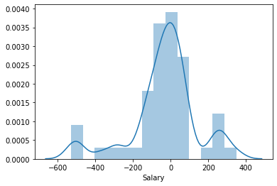

```python
sns.distplot(y_test - y_pred_model8)
```

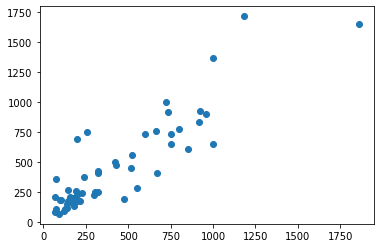

```python
plt.scatter(y_test , y_pred_model8)
```

```python
print('MAE:', metrics.mean_absolute_error(y_test, y_pred_model8))
print('MSE:', metrics.mean_squared_error(y_test, y_pred_model8))
print('RMSE:', np.sqrt(metrics.mean_squared_error(y_test, y_pred_model8)))
```

```
MAE: 121.46096685695623
MSE: 32303.508852903895
RMSE: 179.73176918092108
```

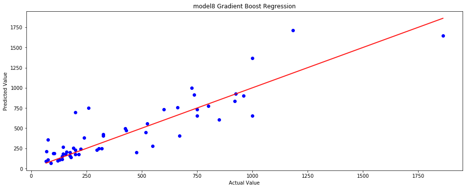

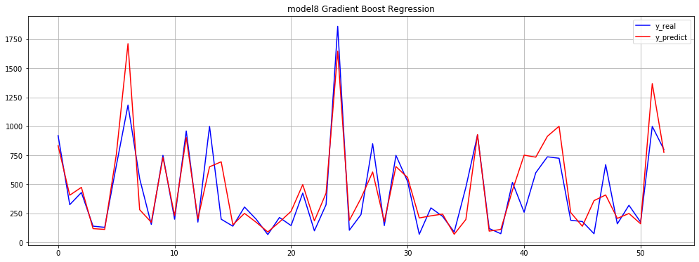

```python
from sklearn.metrics import r2_score

y_pred = y_pred_model8
y_test = y_test
model = 'model8 Gradient Boost Regression'

plt.figure(figsize=(15, 15), dpi = 150);
plt.subplots_adjust(hspace = 0.25, wspace = 0.25);

plt.subplots(figsize=(16,6));
plt.scatter(x = y_test, y = y_pred, color = 'blue');
#Add 45 degree line
xp = np.linspace(y_test.min(), y_test.max(), 100)
plt.plot(xp, xp, 'k', alpha = 0.9, linewidth = 2, color = 'red')
plt.xlabel('Actual Value');
plt.ylabel('Predicted Value');

plt.title(f'{model}');
plt.subplots(figsize=(17,6));

x_points = list(range(len(y_test)));
plt.plot(x_points, y_test, label='y_real', color = 'blue');
plt.plot(x_points, y_pred, label='y_predict', color = 'red');
plt.legend();
plt.grid()
plt.title(f'{model}');
plt.show();
```

```python
model_comp = model_comp.append(pd.DataFrame({'Mean of AbsErrors':    abs_err_model8.mean(),
                                             'Median of AbsErrors' : abs_err_model8.median(),
                                             'SD of AbsErrors' :     abs_err_model8.std(),
                                             'IQR of AbsErrors':     iqr(abs_err_model8),
                                             'Min of AbsErrors':     abs_err_model8.min(),
                                             'Max of AbsErrors':     abs_err_model8.max()}, index = ['Model8: Gradient Boost Regression']),
                               ignore_index = False)

model_comp
```

|  | Mean of AbsErrors | Median of AbsErrors | SD of AbsErrors | IQR of AbsErrors | Min of AbsErrors | Max of AbsErrors |
| --- | --- | --- | --- | --- | --- | --- |
| Model1: Linear-Ragression | 223.148958 | 158.574170 | 198.785517 | 216.725217 | 3.569232 | 1047.957143 |
| Model2: Ridge Regression | 226.441674 | 151.029550 | 293.532084 | 136.707544 | 7.679097 | 1897.768941 |
| Model3: Lasso Regression | 235.833326 | 142.116905 | 324.730397 | 156.625954 | 3.744212 | 2181.596147 |
| Model4: KNN Regression | 160.407478 | 81.167175 | 190.775927 | 226.393202 | 2.543116 | 837.841616 |
| Model5: Decision Tree Regression | 162.989272 | 78.558773 | 185.351198 | 223.772135 | 0.769051 | 827.083624 |
| Model6: Bagging Regression | 108.270063 | 53.318368 | 135.012977 | 139.730651 | 0.721212 | 712.250993 |
| Model7: Random Forest Regression | 116.005541 | 70.955476 | 136.487450 | 163.104426 | 1.779497 | 752.332797 |
| Model8: Gradient Boost Regression | 121.460967 | 68.393246 | 133.746987 | 112.904012 | 3.480469 | 528.954987 |

### Model9: XGBoost

```python
from xgboost import XGBRegressor
from scipy.stats import uniform, randint
```

```python
{'gamma': 0.19993048585762774,
 'learning_rate': 0.04399969896408463,
 'max_depth': 5,
 'n_estimators': 115,
 'subsample': 0.6931085361721216}
```

```
{'gamma': 0.19993048585762774,
 'learning_rate': 0.04399969896408463,
 'max_depth': 5,
 'n_estimators': 115,
 'subsample': 0.6931085361721216}
```

```python
model9 = XGBRegressor(gamma = 0.19993048585762774,
                      learning_rate = 0.04399969896408463,
                      max_depth = 5,
                      n_estimators = 115,
                      subsample = 0.6931085361721216,
                      colsample_bytree = 0.39,
                      reg_alpha = 0.07,
                      reg_lambda = 0.055)
model9.fit(X_train, logy_train)
y_pred_model9 = model9.predict(X_test)
y_pred_model9 = np.exp(y_pred_model9)
abs_err_model9 = np.abs(y_pred_model9 - y_test)
```

params = { "gamma": uniform(0, 0.5), "learning_rate": uniform(0.03, 0.3), # default 0.1 "max_depth": randint(2, 6), # default 3 "n_estimators": randint(100, 150), # default 100 "subsample": uniform(0.6, 0.4) } xgb = RandomizedSearchCV(estimator = model9, param_distributions = params, scoring='neg_mean_squared_error', n_iter = 10, cv = 5, verbose=2, random_state=42, n_jobs = 1) xgb.fit(X_train, logy_train); xgb.best_params_

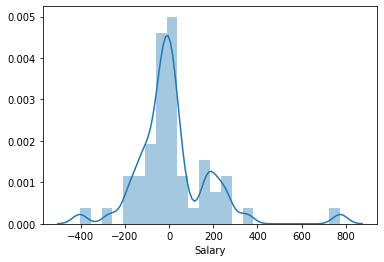

```python
sns.distplot(y_test - y_pred_model9)
```

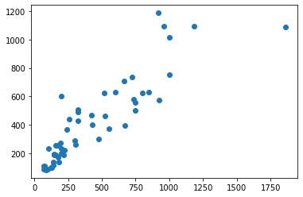

```python
plt.scatter(y_test , y_pred_model9)
```

```python
print('MAE:', metrics.mean_absolute_error(y_test, y_pred_model9))
print('MSE:', metrics.mean_squared_error(y_test, y_pred_model9))
print('RMSE:', np.sqrt(metrics.mean_squared_error(y_test, y_pred_model9)))
```

```
MAE: 111.02415132342644
MSE: 29909.376834659353
RMSE: 172.94327634996208
```

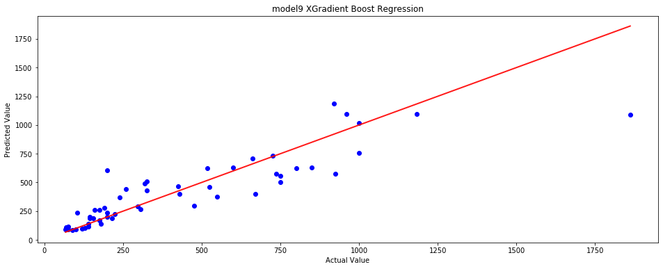

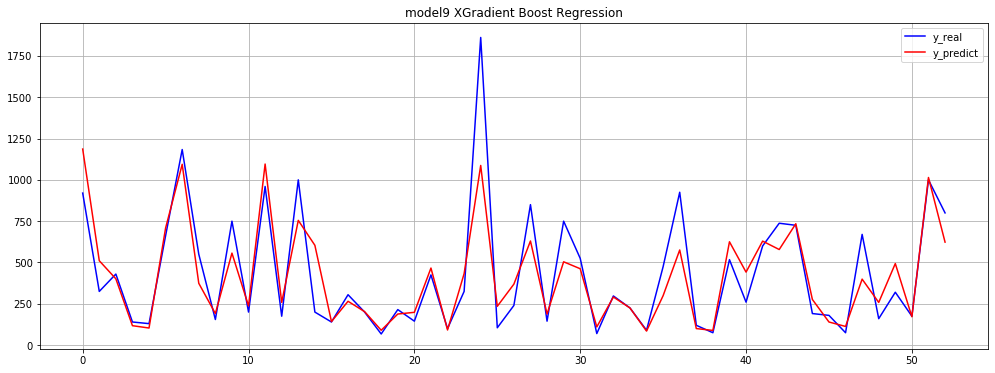

```python
from sklearn.metrics import r2_score

y_pred = y_pred_model9
y_test = y_test
model = 'model9 XGradient Boost Regression'

plt.figure(figsize=(15, 15), dpi = 150);
plt.subplots_adjust(hspace = 0.25, wspace = 0.25);

plt.subplots(figsize=(16,6));
plt.scatter(x = y_test, y = y_pred, color = 'blue');
#Add 45 degree line
xp = np.linspace(y_test.min(), y_test.max(), 100)
plt.plot(xp, xp, 'k', alpha = 0.9, linewidth = 2, color = 'red')
plt.xlabel('Actual Value');
plt.ylabel('Predicted Value');

plt.title(f'{model}');
plt.subplots(figsize=(17,6));

x_points = list(range(len(y_test)));
plt.plot(x_points, y_test, label='y_real', color = 'blue');
plt.plot(x_points, y_pred, label='y_predict', color = 'red');
plt.legend();
plt.grid()
plt.title(f'{model}');
plt.show();
```

```python
model_comp = model_comp.append(pd.DataFrame({'Mean of AbsErrors':    abs_err_model9.mean(),
                                             'Median of AbsErrors' : abs_err_model9.median(),
                                             'SD of AbsErrors' :     abs_err_model9.std(),
                                             'IQR of AbsErrors':     iqr(abs_err_model9),
                                             'Min of AbsErrors':     abs_err_model9.min(),
                                             'Max of AbsErrors':     abs_err_model9.max()}, index = ['Model9: XGradient Boost Regression']),
                               ignore_index = False)

model_comp
```

|  | Mean of AbsErrors | Median of AbsErrors | SD of AbsErrors | IQR of AbsErrors | Min of AbsErrors | Max of AbsErrors |
| --- | --- | --- | --- | --- | --- | --- |
| Model1: Linear-Ragression | 223.148958 | 158.574170 | 198.785517 | 216.725217 | 3.569232 | 1047.957143 |
| Model2: Ridge Regression | 226.441674 | 151.029550 | 293.532084 | 136.707544 | 7.679097 | 1897.768941 |
| Model3: Lasso Regression | 235.833326 | 142.116905 | 324.730397 | 156.625954 | 3.744212 | 2181.596147 |
| Model4: KNN Regression | 160.407478 | 81.167175 | 190.775927 | 226.393202 | 2.543116 | 837.841616 |
| Model5: Decision Tree Regression | 162.989272 | 78.558773 | 185.351198 | 223.772135 | 0.769051 | 827.083624 |
| Model6: Bagging Regression | 108.270063 | 53.318368 | 135.012977 | 139.730651 | 0.721212 | 712.250993 |
| Model7: Random Forest Regression | 116.005541 | 70.955476 | 136.487450 | 163.104426 | 1.779497 | 752.332797 |
| Model8: Gradient Boost Regression | 121.460967 | 68.393246 | 133.746987 | 112.904012 | 3.480469 | 528.954987 |
| Model9: XGradient Boost Regression | 111.024151 | 53.490540 | 133.869898 | 149.096519 | 0.053513 | 774.368569 |

### Model10: CatBoost

```python
from catboost import CatBoostRegressor
model10 = CatBoostRegressor(learning_rate = 0.03,
                            l2_leaf_reg = 5,
                            depth = 10, verbose = 0)
model10.fit(X_train, logy_train);
y_pred_model10 = model10.predict(X_test)
y_pred_model10 = np.exp(y_pred_model10)
abs_err_model10 = np.abs(y_pred_model10 - y_test)
```

grid = {'learning_rate': [0.03, 0.1], 'depth': [4, 6, 10], 'l2_leaf_reg': [1, 3, 5, 7, 9]} cb = RandomizedSearchCV(estimator = model10, param_distributions = grid, scoring='neg_mean_squared_error', n_iter = 10, cv = 5, verbose=2, random_state=42, n_jobs = 1) cb.fit(X_train,logy_train); cb.best_params_

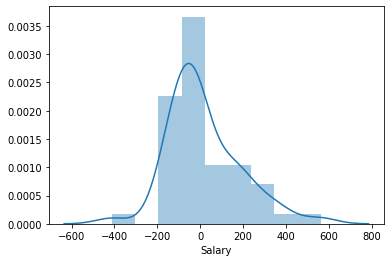

```python
sns.distplot(y_test - y_pred_model10)
```

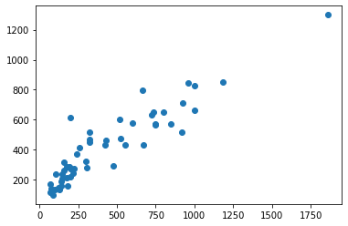

```python
plt.scatter(y_test , y_pred_model10)
```

```python
print('MAE:', metrics.mean_absolute_error(y_test, y_pred_model10))
print('MSE:', metrics.mean_squared_error(y_test, y_pred_model10))
print('RMSE:', np.sqrt(metrics.mean_squared_error(y_test, y_pred_model10)))
```

```
MAE: 124.36481600298288
MSE: 28645.260923268437
RMSE: 169.2491090767347
```

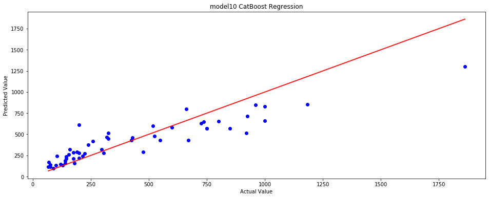

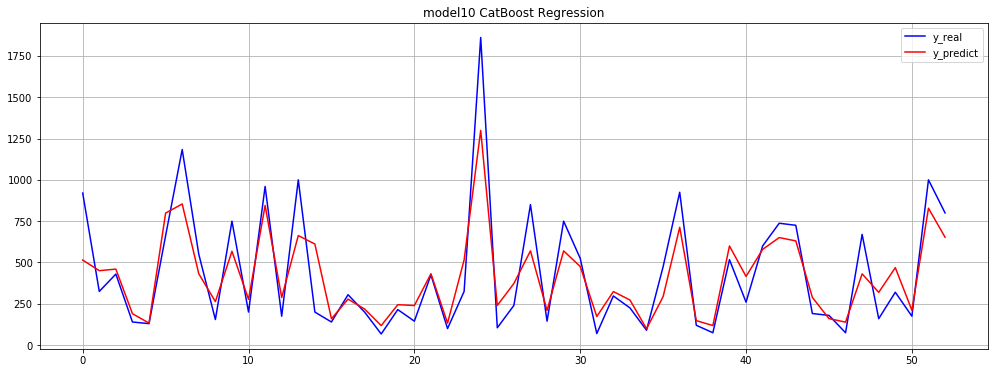

```python
from sklearn.metrics import r2_score

y_pred = y_pred_model10
y_test = y_test
model = 'model10 CatBoost Regression'

plt.figure(figsize=(15, 15), dpi = 150);
plt.subplots_adjust(hspace = 0.25, wspace = 0.25);

plt.subplots(figsize=(16,6));
plt.scatter(x = y_test, y = y_pred, color = 'blue');
#Add 45 degree line
xp = np.linspace(y_test.min(), y_test.max(), 100)
plt.plot(xp, xp, 'k', alpha = 0.9, linewidth = 2, color = 'red')
plt.xlabel('Actual Value');
plt.ylabel('Predicted Value');

plt.title(f'{model}');
plt.subplots(figsize=(17,6));

x_points = list(range(len(y_test)));
plt.plot(x_points, y_test, label='y_real', color = 'blue');
plt.plot(x_points, y_pred, label='y_predict', color = 'red');
plt.legend();
plt.grid()
plt.title(f'{model}');
plt.show();
```

```python
model_comp = model_comp.append(pd.DataFrame({'Mean of AbsErrors':    abs_err_model10.mean(),
                                             'Median of AbsErrors' : abs_err_model10.median(),
                                             'SD of AbsErrors' :     abs_err_model10.std(),
                                             'IQR of AbsErrors':     iqr(abs_err_model10),
                                             'Min of AbsErrors':     abs_err_model10.min(),
                                             'Max of AbsErrors':     abs_err_model10.max()}, index = ['Model10: CatBoost Regression']),
                               ignore_index = False)

model_comp
```

|  | Mean of AbsErrors | Median of AbsErrors | SD of AbsErrors | IQR of AbsErrors | Min of AbsErrors | Max of AbsErrors |
| --- | --- | --- | --- | --- | --- | --- |
| Model1: Linear-Ragression | 223.148958 | 158.574170 | 198.785517 | 216.725217 | 3.569232 | 1047.957143 |
| Model2: Ridge Regression | 226.441674 | 151.029550 | 293.532084 | 136.707544 | 7.679097 | 1897.768941 |
| Model3: Lasso Regression | 235.833326 | 142.116905 | 324.730397 | 156.625954 | 3.744212 | 2181.596147 |
| Model4: KNN Regression | 160.407478 | 81.167175 | 190.775927 | 226.393202 | 2.543116 | 837.841616 |
| Model5: Decision Tree Regression | 162.989272 | 78.558773 | 185.351198 | 223.772135 | 0.769051 | 827.083624 |
| Model6: Bagging Regression | 108.270063 | 53.318368 | 135.012977 | 139.730651 | 0.721212 | 712.250993 |
| Model7: Random Forest Regression | 116.005541 | 70.955476 | 136.487450 | 163.104426 | 1.779497 | 752.332797 |
| Model8: Gradient Boost Regression | 121.460967 | 68.393246 | 133.746987 | 112.904012 | 3.480469 | 528.954987 |
| Model9: XGradient Boost Regression | 111.024151 | 53.490540 | 133.869898 | 149.096519 | 0.053513 | 774.368569 |
| Model10: CatBoost Regression | 124.364816 | 97.575426 | 115.896890 | 123.215817 | 3.237146 | 562.148719 |

### Model11: LightBoost

```python
from lightgbm import LGBMRegressor
model11 = LGBMRegressor(gamma = 0.22007624686980065,
                        learning_rate = 0.06661147045343364,
                        max_depth = 2,
                        n_estimators = 107,
                        subsample = 0.6137554084460873)
model11.fit(X_train, logy_train)
y_pred_model11 = model11.predict(X_test)
y_pred_model11 = np.exp(y_pred_model11)
abs_err_model11 = np.abs(y_pred_model11 - y_test)
```

```
[LightGBM] [Warning] Unknown parameter: gamma
```

params = { "gamma": uniform(0, 0.5), "learning_rate": uniform(0.03, 0.3), # default 0.1 "max_depth": randint(2, 6), # default 3 "n_estimators": randint(100, 150), # default 100 "subsample": uniform(0.6, 0.4) } lb = RandomizedSearchCV(estimator = model11, param_distributions = params, scoring='neg_mean_squared_error', n_iter = 10, cv = 5, verbose=2, random_state=42, n_jobs = 1) lb.fit(X_train, logy_train); lb.best_params_

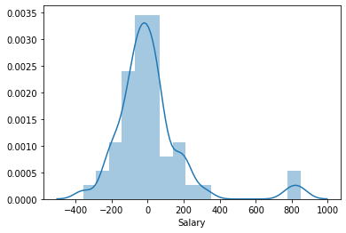

```python
sns.distplot(y_test - y_pred_model11)
```

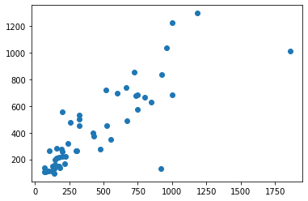

```python
plt.scatter(y_test , y_pred_model11)
```

```python
print('MAE:', metrics.mean_absolute_error(y_test, y_pred_model11))
print('MSE:', metrics.mean_squared_error(y_test, y_pred_model11))
print('RMSE:', np.sqrt(metrics.mean_squared_error(y_test, y_pred_model11)))
```

```
MAE: 124.93325779962663
MSE: 41085.0395500319
RMSE: 202.69444874004787
```

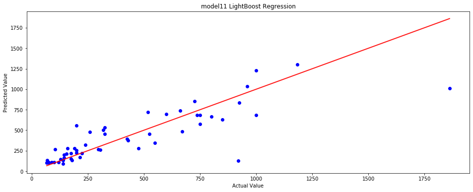

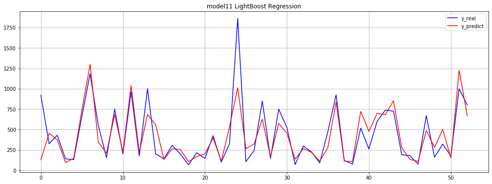

```python
from sklearn.metrics import r2_score

y_pred = y_pred_model11
y_test = y_test
model = 'model11 LightBoost Regression'

plt.figure(figsize=(15, 15), dpi = 150);
plt.subplots_adjust(hspace = 0.25, wspace = 0.25);

plt.subplots(figsize=(16,6));
plt.scatter(x = y_test, y = y_pred, color = 'blue');
#Add 45 degree line
xp = np.linspace(y_test.min(), y_test.max(), 100)
plt.plot(xp, xp, 'k', alpha = 0.9, linewidth = 2, color = 'red')
plt.xlabel('Actual Value');
plt.ylabel('Predicted Value');

plt.title(f'{model}');
plt.subplots(figsize=(17,6));

x_points = list(range(len(y_test)));
plt.plot(x_points, y_test, label='y_real', color = 'blue');
plt.plot(x_points, y_pred, label='y_predict', color = 'red');
plt.legend();
plt.grid()
plt.title(f'{model}');
plt.show();
```

```python
model_comp = model_comp.append(pd.DataFrame({'Mean of AbsErrors':    abs_err_model11.mean(),
                                             'Median of AbsErrors' : abs_err_model11.median(),
                                             'SD of AbsErrors' :     abs_err_model11.std(),
                                             'IQR of AbsErrors':     iqr(abs_err_model11),
                                             'Min of AbsErrors':     abs_err_model11.min(),
                                             'Max of AbsErrors':     abs_err_model11.max()}, index = ['Model11: LightBoost Regression']),
                               ignore_index = False)

model_comp
```

|  | Mean of AbsErrors | Median of AbsErrors | SD of AbsErrors | IQR of AbsErrors | Min of AbsErrors | Max of AbsErrors |
| --- | --- | --- | --- | --- | --- | --- |
| Model1: Linear-Ragression | 223.148958 | 158.574170 | 198.785517 | 216.725217 | 3.569232 | 1047.957143 |
| Model2: Ridge Regression | 226.441674 | 151.029550 | 293.532084 | 136.707544 | 7.679097 | 1897.768941 |
| Model3: Lasso Regression | 235.833326 | 142.116905 | 324.730397 | 156.625954 | 3.744212 | 2181.596147 |
| Model4: KNN Regression | 160.407478 | 81.167175 | 190.775927 | 226.393202 | 2.543116 | 837.841616 |
| Model5: Decision Tree Regression | 162.989272 | 78.558773 | 185.351198 | 223.772135 | 0.769051 | 827.083624 |
| Model6: Bagging Regression | 108.270063 | 53.318368 | 135.012977 | 139.730651 | 0.721212 | 712.250993 |
| Model7: Random Forest Regression | 116.005541 | 70.955476 | 136.487450 | 163.104426 | 1.779497 | 752.332797 |
| Model8: Gradient Boost Regression | 121.460967 | 68.393246 | 133.746987 | 112.904012 | 3.480469 | 528.954987 |
| Model9: XGradient Boost Regression | 111.024151 | 53.490540 | 133.869898 | 149.096519 | 0.053513 | 774.368569 |
| Model10: CatBoost Regression | 124.364816 | 97.575426 | 115.896890 | 123.215817 | 3.237146 | 562.148719 |
| Model11: LightBoost Regression | 124.933258 | 71.528389 | 161.141731 | 136.835531 | 5.743488 | 849.233318 |

```python
# Seeing The Resualt you can choose a model :
# I think Model9 and Model6 is Good in this case
```